# Descriptive Statistics & EpiAnalyses Report

Dewi Anastasia Christina

05 April 2025

## 1. Descriptive statistics

### 1.1. Methods

To ensure accuracy on species identification, we evaluated the quality of genome assembly using **Bioconda::assembly-stats** (developed by Sanger Pathogens) and classified genomes into two categories: those with a genome length 1.9 Mb-2.3 Mb were considered pure pneumococcal genomes while those outside the ranges were classified as pneumococcal genomes with intra-species contamination. Further validation was performed using Torsten Seemann’s **MLST** toolset, which conducts **BLAST** analysis on seven housekeeping genes. Multiple-serotype contamination was examined using Sheppard et al.’s **pneumoKITy**. Additionally, we uploaded the data to PathogenWatch (http://pathogen.watch) to obtain *in silico* identification of pneumococcus including their serotype determination, Global Pneumococcal Sequence Cluster (GPSC) classification, sequence type (ST), and antibiotic resistance profiling.

The vaccine serotypes included in PCV13 (1, 3, 4, 5, 6A, 6B, 7F, 9V, 14, 18C, 19A, 19F, and 23F). *S. pneumoniae* were classified as non-typeable if a serotype could not be determined *in silico*.

### 1.2. Results

### 1.2.1. EpiData

#### Data characteristics

A total number of 900 children were evenly assessed from Lombok (50%, n = 450) and Sumbawa (50%, n = 450), with equally represented males and females (48.78%, n = 439; 51.22%, n = 461, respectively). Overall, the study was dominated by children aged 3-5 years old (41.22%, n = 371), followed by children aged 1-2 years old (39.56% (39.56%, n = 356) and children below a year (19.22%, n = 173). 97.67% of the children (n = 879) were not consuming antibiotic in the past a month. Most of the children were currently breastfeed (50.44%, n = 454) or ever breastfeed (46.56%, n = 419), with only 3% of the children were never breastfed (n = 27).

#### Pneumococcal carriage

The pneumococcal carriage rate was slightly lower among males (42.82% (188/439)) compared to females (45.12% (208/461)). A slightly higher pneumococcal carriage was observed in Sumbawa (n = 204, 45.33%) compared to Lombok (n = 192, 42.67%). Among children assessed in Lombok, 3.78% (17/450) were under 1 year of age, with a pneumococcal carriage rate of 47.06% (8/17). In Sumbawa, 34.67% (156/450) of children were under 1 year, with a similar carriage rate of 44.87% (70/156).

Children who received three doses of the Hib pentavalent vaccine accounted for 51% (n = 459) of the study population, with a carriage rate of 45.1% (n = 207). Those who received four doses made up 49% (n = 441), with a slightly lower positivity rate of 42.86% (n = 189). Children who received one to two mandatory doses of the PCV13 accounted for 40.56% (n = 365) of the study population, with a positivity rate of 41.37% (n = 151). Those who received three to four doses made up 59.44% (n = 535), with a slightly higher positivity rate of 45.79% (n = 245).

Table 1

|  | variable | value | assessed_lombok | positive_lombok | assessed_sumbawa | positive_sumbawa | assessed_all | positive_all | estimate | lower | upper | midp.exact | fisher.exact | chi.square | significance |
| --- | --- | --- | --- | --- | --- | --- | --- | --- | --- | --- | --- | --- | --- | --- | --- |
| 1 | age_year_3groups | 1 and below | 3.78% (17/450) | 47.06% (8/17) | 34.67% (156/450) | 44.87% (70/156) | 19.22% (173/900) | 45.09% (78/173) | 0.128 | 0.072 | 0.214 | 0 | 0 | 0 | occur |
| 2 | age_year_3groups | 1-2 | 36.67% (165/450) | 46.67% (77/165) | 42.44% (191/450) | 46.6% (89/191) | 39.56% (356/900) | 46.63% (166/356) | 0.128 | 0.072 | 0.214 | 0 | 0 | 0 | occur |
| 3 | age_year_3groups | 3-5 | 59.56% (268/450) | 39.93% (107/268) | 22.89% (103/450) | 43.69% (45/103) | 41.22% (371/900) | 40.97% (152/371) | 0.128 | 0.072 | 0.214 | 0 | 0 | 0 | occur |
| 4 | antibiotic_past1mo | no | 98.89% (445/450) | 42.92% (191/445) | 96.44% (434/450) | 45.85% (199/434) | 97.67% (879/900) | 44.37% (390/879) | 3.208 | 1.233 | 10.08 | 0.016 | 0.025 | 0.015 | occur |
| 5 | antibiotic_past1mo | yes | 1.11% (5/450) | 20% (1/5) | 3.56% (16/450) | 31.25% (5/16) | 2.33% (21/900) | 28.57% (6/21) | 3.208 | 1.233 | 10.08 | 0.016 | 0.025 | 0.015 | occur |
| 6 | breastFeed_compiled | currently breastfeed | 33.33% (150/450) | 48.67% (73/150) | 67.56% (304/450) | 45.39% (138/304) | 50.44% (454/900) | 46.48% (211/454) | 0.21 | 0.158 | 0.279 | 0 | 0 | 0 | occur |
| 7 | breastFeed_compiled | ever breastfeed | 65.33% (294/450) | 39.46% (116/294) | 27.78% (125/450) | 44.8% (56/125) | 46.56% (419/900) | 41.05% (172/419) | 0.21 | 0.158 | 0.279 | 0 | 0 | 0 | occur |
| 8 | breastFeed_compiled | never breastfeed | 1.33% (6/450) | 50% (3/6) | 4.67% (21/450) | 47.62% (10/21) | 3% (27/900) | 48.15% (13/27) | 0.21 | 0.158 | 0.279 | 0 | 0 | 0 | occur |
| 9 | contact_cigarettes | no | 84% (378/450) | 43.39% (164/378) | 52.67% (237/450) | 41.35% (98/237) | 68.33% (615/900) | 42.6% (262/615) | 4.704 | 3.455 | 6.465 | 0 | 0 | 0 | occur |
| 10 | contact_cigarettes | yes | 16% (72/450) | 38.89% (28/72) | 47.33% (213/450) | 49.77% (106/213) | 31.67% (285/900) | 47.02% (134/285) | 4.704 | 3.455 | 6.465 | 0 | 0 | 0 | occur |

[output cut: 35 more lines]

### 1.2.2. Genome data

Filter out the data:

From positive samples, how many data failed to be processed due to RNA contaminations, etc.

Subset the data to only WGS-processed samples:

MLST, pneumoKITy and contamination profiles.

vaccine-types and non-vaccine-types

[figure not shown]

## 2. Modelling

### 2.2. Results

### 2.2.1. EpiData

|  | variable | value | univar_crude_OR_report | univar_crude_p.value | univar_plusArea_report | univar_plusArea_p.value | multivar_model1_report_OR | multivar_model1_p_value | multivar_final_report_OR | multivar_final_prz |
| --- | --- | --- | --- | --- | --- | --- | --- | --- | --- | --- |
| 1 | age_year_3groups | (Intercept) | 0.82 (0.61-1.11) | 0.2 | 0.78 (0.52-1.17) | 0.23 | 2.23 (0.54-9.13) | 0.27 | 0.9 (0.62-1.3) | 0.57 |
| 2 | age_year_3groups | age_year_3groups1-2 | 1.06 (0.74-1.53) | 0.74 | 1.09 (0.74-1.59) | 0.67 | 0.85 (0.51-1.41) | 0.53 | NA (NA-NA) |  |
| 3 | age_year_3groups | age_year_3groups3-5 | 0.85 (0.59-1.22) | 0.37 | 0.87 (0.58-1.32) | 0.52 | 0.78 (0.42-1.44) | 0.43 | NA (NA-NA) |  |
| 4 | age_year_3groups | areasumbawa |  |  | 1.06 (0.79-1.42) | 0.72 | 2.35 (0.35-19.34) | 0.38 | NA (NA-NA) |  |
| 5 | antibiotic_past1mo | (Intercept) | 0.8 (0.7-0.91) | 0 | 0.75 (0.62-0.9) | 0 | 2.23 (0.54-9.13) | 0.27 | 0.9 (0.62-1.3) | 0.57 |
| 6 | antibiotic_past1mo | antibiotic_past1moyes | 0.5 (0.19-1.3) | 0.16 | 0.48 (0.19-1.27) | 0.14 | 0.59 (0.2-1.58) | 0.31 | NA (NA-NA) |  |
| 7 | antibiotic_past1mo | areasumbawa |  |  | 1.13 (0.87-1.48) | 0.35 | 2.35 (0.35-19.34) | 0.38 | NA (NA-NA) |  |
| 8 | antibiotic_past3days | (Intercept) | 0.78 (0.68-0.89) | 0 | 0.74 (0.61-0.89) | 0 | 2.23 (0.54-9.13) | 0.27 | 0.9 (0.62-1.3) | 0.57 |
| 9 | antibiotic_past3days | antibiotic_past3daysunknown | 366869.38 (0-9.81594644739974e+281) | 0.97 | 388305.96 (0-1.03896467582815e+282) | 0.97 | 1590421.96 (0-NA) | 0.98 | NA (NA-NA) |  |
| 10 | antibiotic_past3days | antibiotic_past3daysyes | 1.15 (0.46-2.86) | 0.76 | 1.15 (0.46-2.86) | 0.77 | 1.17 (0.41-3.29) | 0.77 | NA (NA-NA) |  |

[output cut: 88 more lines]

|  | variable | value | univar_crude_OR_report | univar_crude_p.value | univar_plusArea_report | univar_plusArea_p.value | multivar_model1_report_OR | multivar_model1_p_value | multivar_final_report_OR | multivar_final_prz |
| --- | --- | --- | --- | --- | --- | --- | --- | --- | --- | --- |
| 1 | contact_otherChildren | contact_otherChildrenyes | 0.76 (0.51-1.11) | 0.16 | 0.67 (0.44-1.01) | 0.06 | 0.6 (0.37-0.97) | 0.04 | 0.71 (0.48-1.05) | 0.09 |
| 2 | illness_past24h_cough | illness_past24h_coughyes | 1.19 (0.8-1.77) | 0.4 | 1.16 (0.77-1.74) | 0.47 | 0.57 (0.32-1) | 0.05 | 0.68 (0.4-1.13) | 0.13 |
| 3 | illness_past24h_difficulty_compiled | illness_past24h_difficulty_compiled≥ 1 respiratory illness | 1.67 (1.24-2.25) | 0 | 1.67 (1.23-2.27) | 0 | 2.84 (1-8.27) | 0.05 | 2.04 (1.39-3) | 0 |
| 4 | n_child_1to2yo | n_child_1to2yo | 1.86 (0.84-4.08) | 0.12 | 1.88 (0.85-4.12) | 0.12 | 2.32 (0.97-5.85) | 0.06 | 1.8 (0.81-4.2) | 0.16 |

Sort of goodness of fit

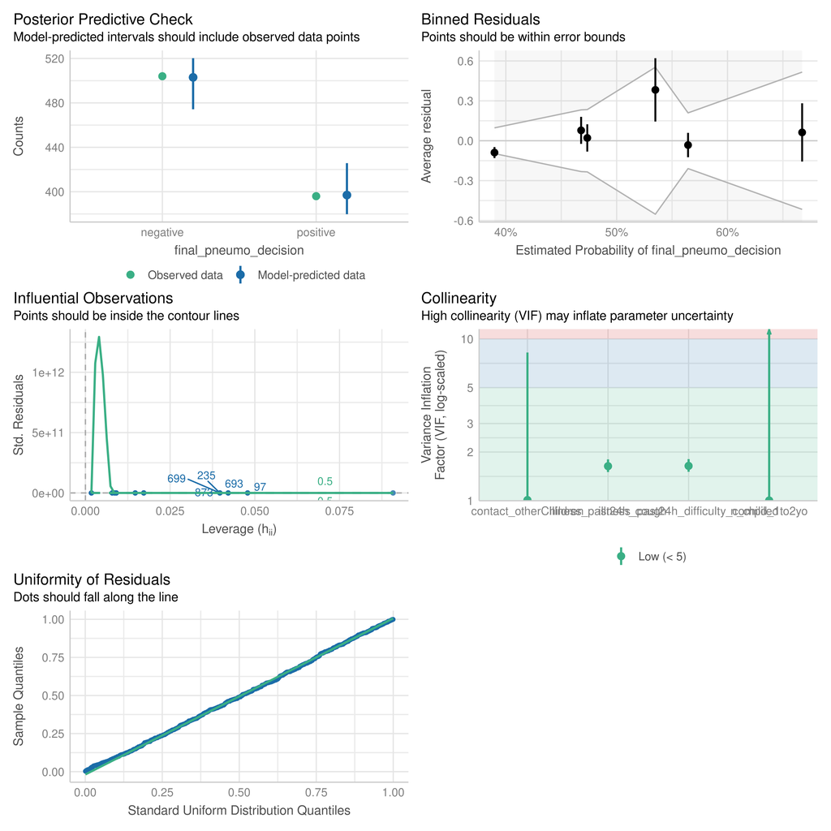

However, the analysis indicated that area was not a confounder

### 2.2.2. Genome data

Multivariate analyses for serotype related to carriage, vaccine types and non-vaccine types,

## 3. Discussion and conclusion